# How Low Income White Americans Vote

Rohan Uppuluri

9/23/2020

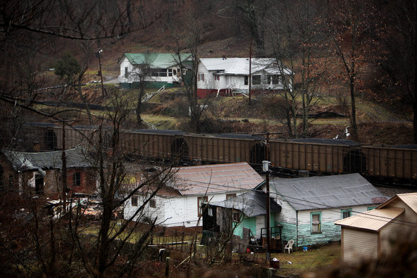

(image source: https://www.nytimes.com/times-insider/2014/04/23/penetrating-a-closed-isolated-society-in-appalachia/)

## Introduction

The Republican party tends to believe that the government should play a smaller role in people’s lives, especially in the economy (https://www.britannica.com/topic/Republican-Party), while the Democratic party supports the idea of a larger government that provides more aid to the people (https://www.britannica.com/topic/Democratic-Party). Because Democrats favor government programs like welfare, in theory it would make sense for low income voters to vote Democrat more than Republican.

We will examine the voting behavior of low income, specifically white Americans, to see if this idea holds. In particular, we hope to answer the following questions:

-What is the presidential voting behavior of low income white Americans?

-What are some of the demographic differences between low income white Democrats and Republicans that could help explain their voting behavior?

## Preliminaries and Biases

We will be using the ANES time series data (1948-2016) to analyze the voting behavior and demographic information of low income white Americans. For the sake of this analysis, we will define low income as 0 to 33 percentile.

We will only examine voting behavior of low income white Democrats and Republicans. There is not as much data on Independent voters compared to that of the two main parties, and different Independent candidates throughout the years do not necessarily share the same ideologies. Hence, it would be harder to narrow in on demographics of Independent voters throughout the years, so we will omit them from this analysis.

Normally, analyzing income data from surveys can be problematic since income can be an uncomfortable topic to discuss for some people, and this opens up the possibility of some respondents claiming to be in a higher income level than they actually are. However, a respondent has less incentive to lie about being in a lower income level than being in a higher income level. Thus, by analyzing low income voters instead of medium to high income voters, we remove some of this self-reporting bias.

## Income Breakdown of Voters

First, let’s do an income breakdown of all Democrat and Republican voters throughout the election years. Although there are some years where the very wealthy (96 to 100 percentile) have a smaller proportion of Republican voters compared to the other income groups, it looks like that for the most part, lower income Americans are more likely to vote Democrat and higher income Americans are more likely to vote Republican.

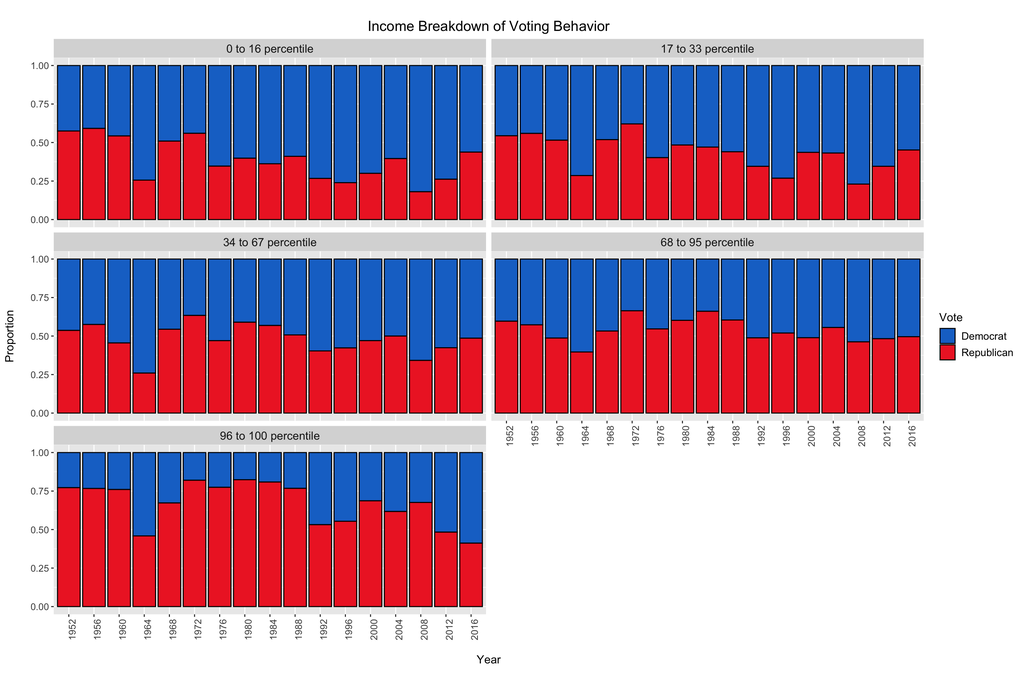

## Racial Breakdown of Income Levels

However, now let’s look at what happens when we further break income levels down by race. It looks like income is not as related to voting behavior as had been indicated by the previous graphs. White Americans mostly vote Republican, and non white Americans mostly vote Democrat, regardless of income level.

The results from the previous graphs most likely stem from the fact that there are significantly more white Americans than non white Americans who participated in the survey, which skewed the vote proportion toward white voter behavior.

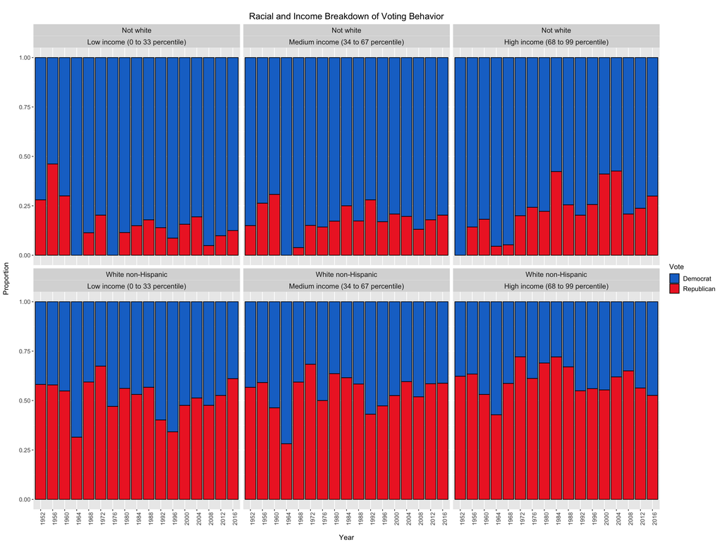

This phenomenon of low income white Americans mostly Republican even if the Democratic party would theoretically offer more aid to them is a bit peculiar. To understand why this could be the case, we will examine the differences between white Republicans and low income white Democrats.

Note that the ANES data has significantly more white participants than people of color, especially before 1980, so for the rest of the analysis we will not focus on non white Americans because a lack of data means it will be harder to narrow in on demographics within non white Americans.

## Differences in Religion

Regardless of the party, most low income white Americans are Christian (Protestant or Catholic), but a significantly higher proportion of Republicans are Protestant compared to the proportion of Protestants among Democrats.

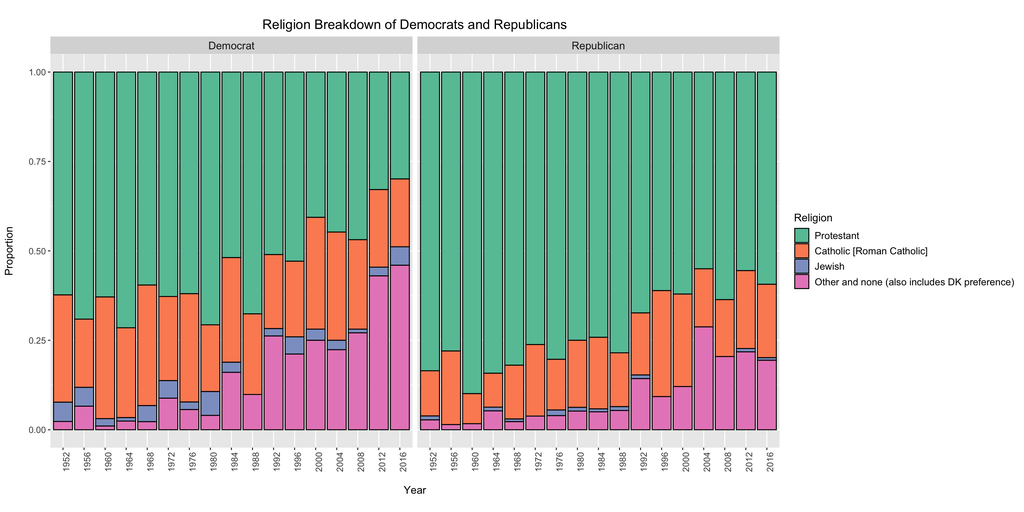

Of the low income white Americans who are Christian, a higher proportion of Republicans believe in a fundamentalist interpretation of the Bible compared to Democrats. Moreover, a significantly higher amount of Democrats do not believe in the Bible at all despite being Christian, indicating that Christianity plays a more important role in Republicans’ lives than Democrats. Note that the three main answers for this survey question do not seem to capture all the possible feelings a voter can have toward the Bible, so I have kept in the Other/DK respondents as a valid response.

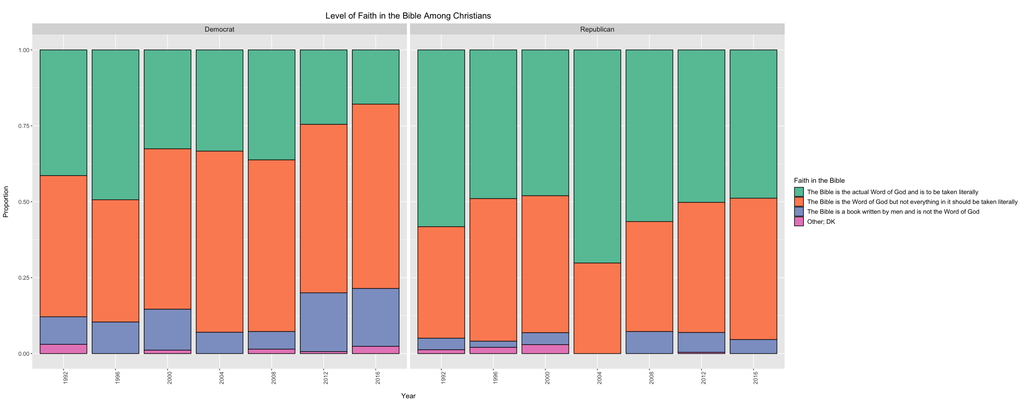

Of the low income white Americans who are Christians, Republicans have had higher church attendance than Democrats, which reinforces that Christianity plays a larger role in Republicans’ lives.

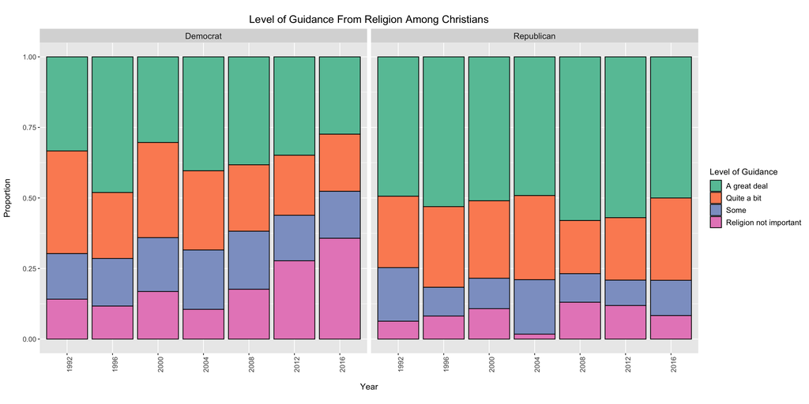

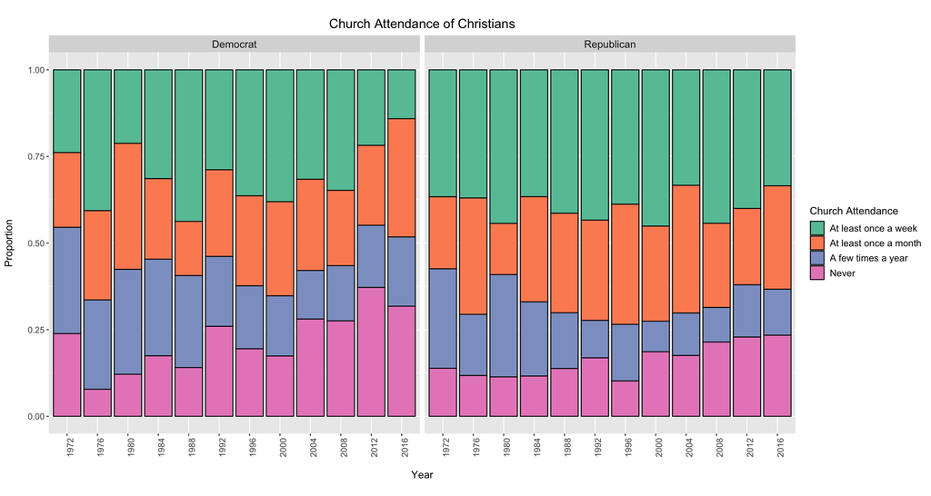

## Differences in Views on Traditional Values and Government

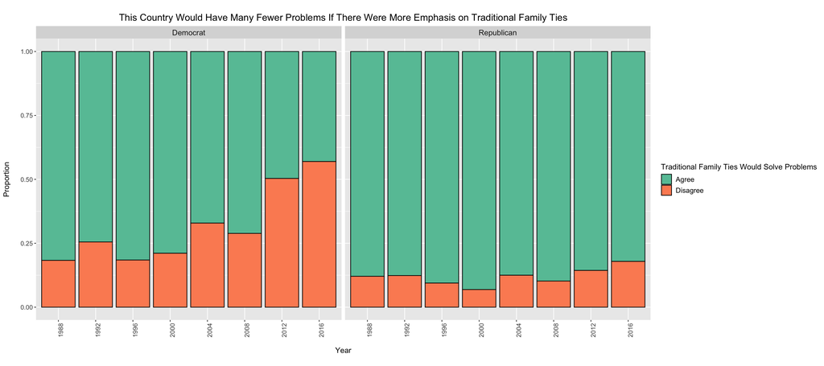

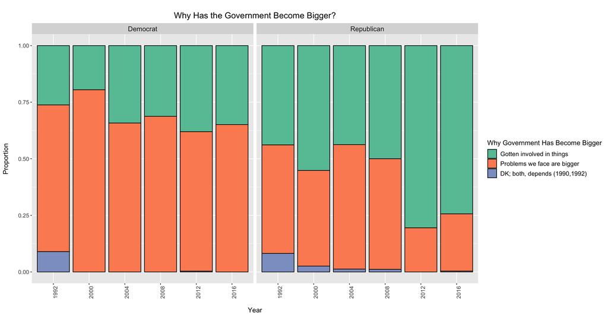

In terms of specific government programs, more Republicans want welfare and other aid programs to low income Americans to stay the same/decrease compared to Democrats. The Republican belief falls in line with how they mostly want less government control in their lives, especially in the economy, so it looks like the belief in less government overrides their desire for an increase in financial security despite the fact that they have little income.

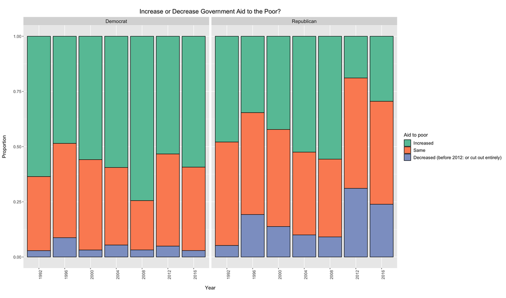

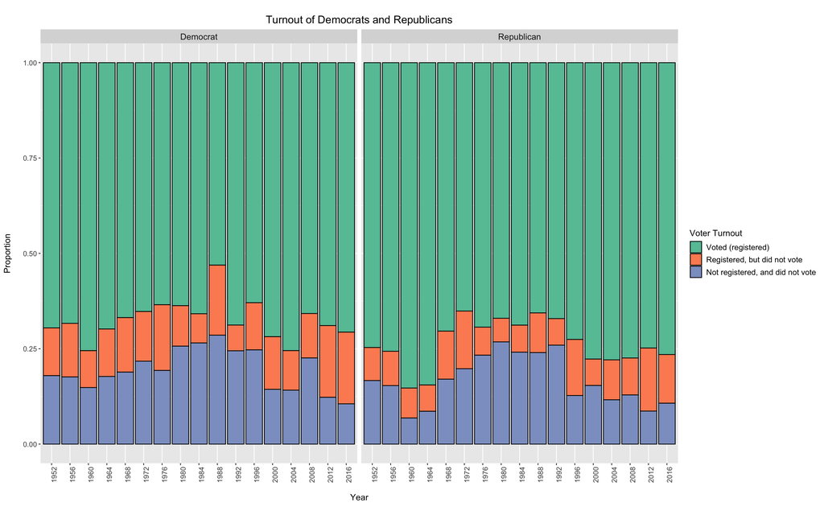

## Conclusion

In conclusion, this analysis indicates that low income white Americans mostly vote Republican, and low income non white Americans mostly vote Democrat.

Despite the fact that Democrats offer more government aid programs, most low income white Republicans emphasize family ties and a strong relationship with Christianity and their church to help with their everyday problems instead of the government.

On the other hand, most low income white Democrats’ are Christian as well, but religion plays less of a role in their lives, and they believe more in government aid like welfare programs.

However, there could be additional variables in the survey we did not explore or even variables that were not in the survey at all that could explain more about these differences in voting behavior. Note that attributes like age, gender, occupation, region, and education levels did not seem to indicate that a person would be more likely to vote Democrat or Republican, but I have omitted this result from the analysis to focus more on differences rather than similarities.

Finally, although we now know more about the demographic differences betweeen low income white Republicans and low income white Democrats, we still do not actually know for sure if these differences are merely correlated with their voting decisions or if they actually cause them to vote the way they do. We would need to use some causal inference techniques on the survey results or go beyond the results of the survey to determine actual causal effects on low income white Americans’ voting behavior.